# Parkinson’s Classification Ensemble

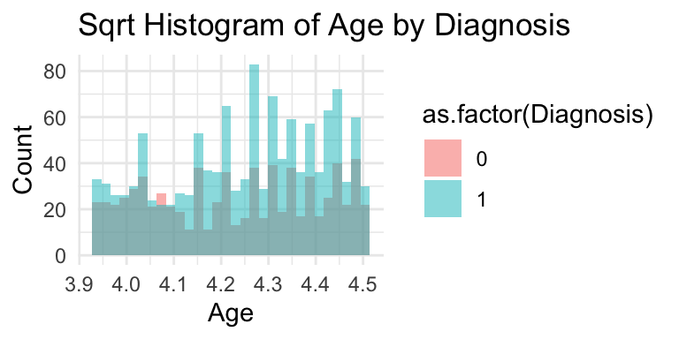

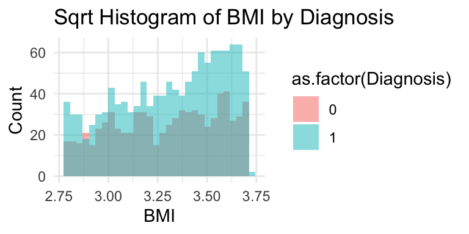

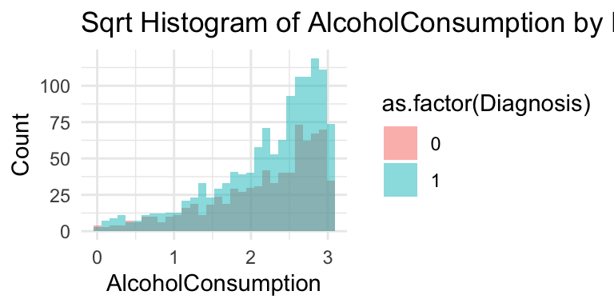

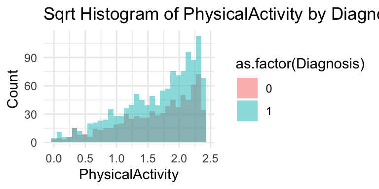

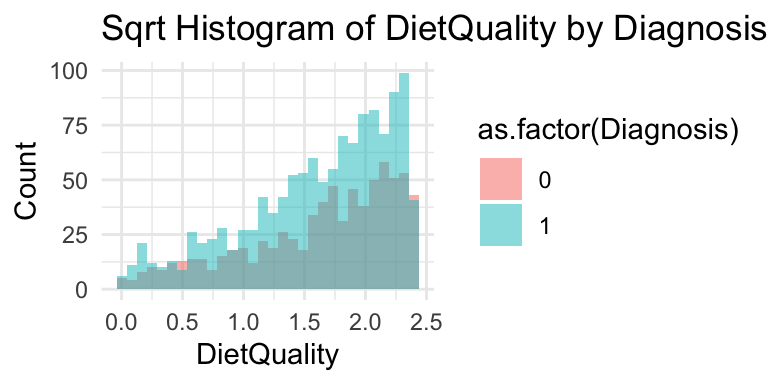

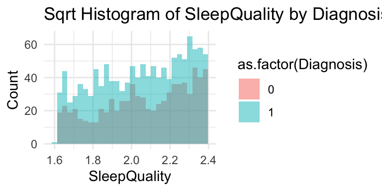

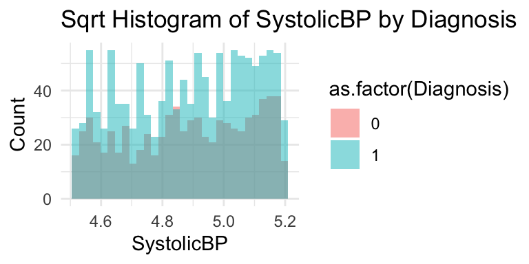

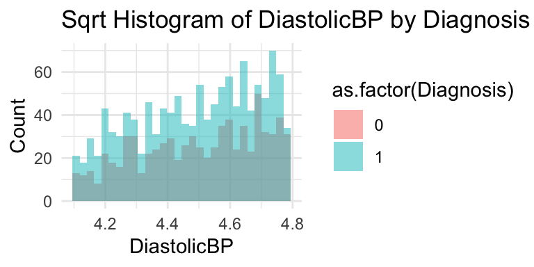

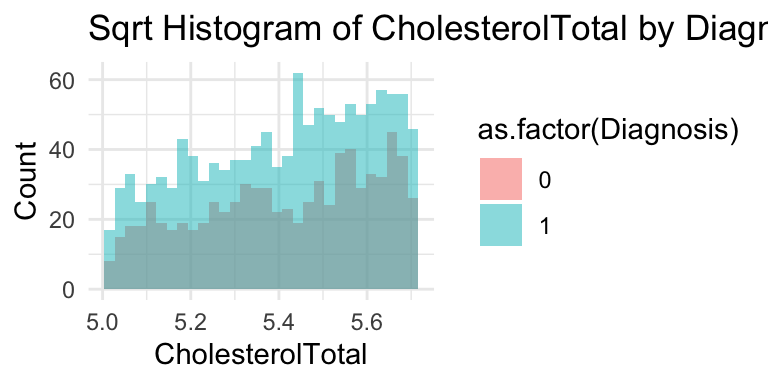

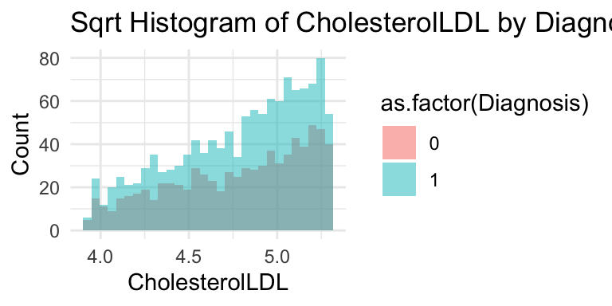

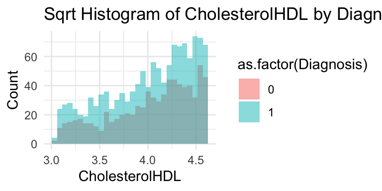

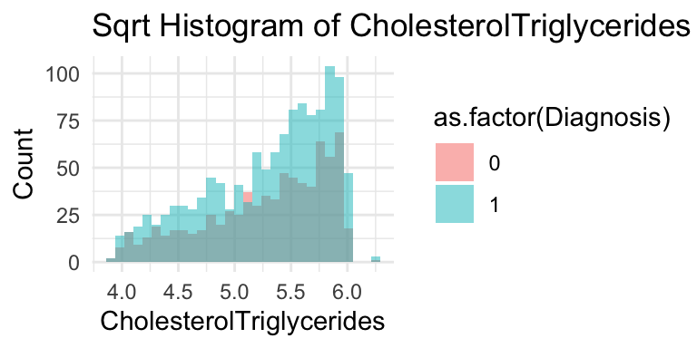

[3 more figures not shown]

```r
# create df for sqrt transformed num feat for easy viewing
df_sqrt <- rf_df %>%
  mutate(across(all_of(numeric_features), ~ sqrt(.x)))

# view dist
numericDist(df_log, numeric_features, target, "Sqrt")
```

##### Categorical Features

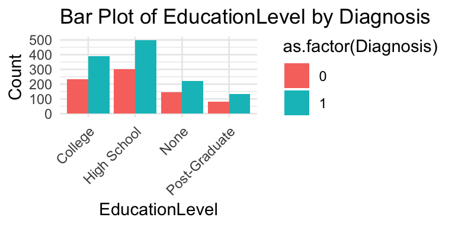

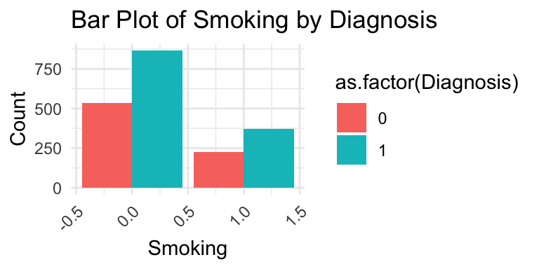

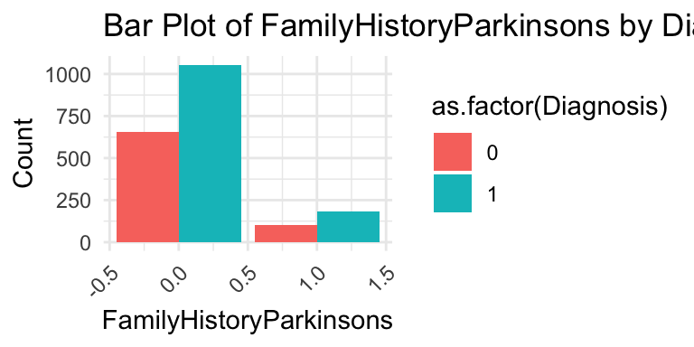

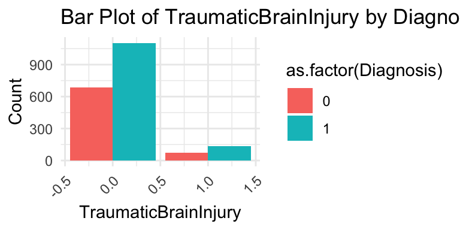

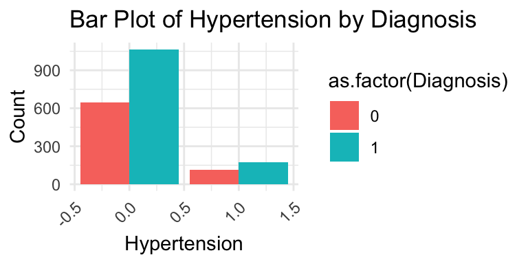

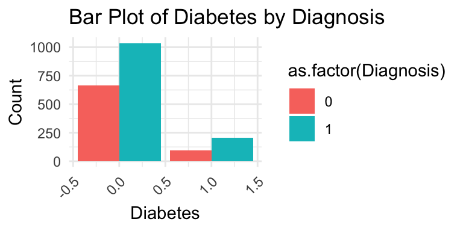

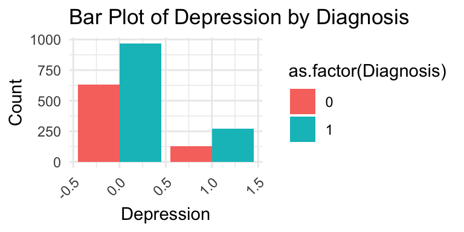

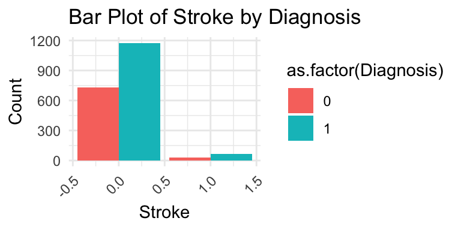

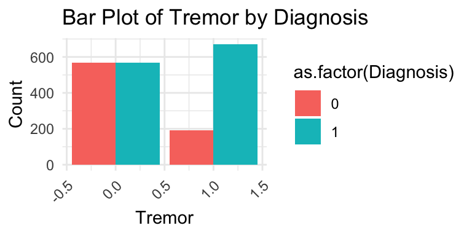

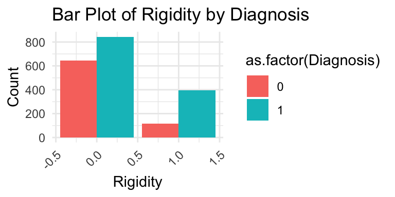

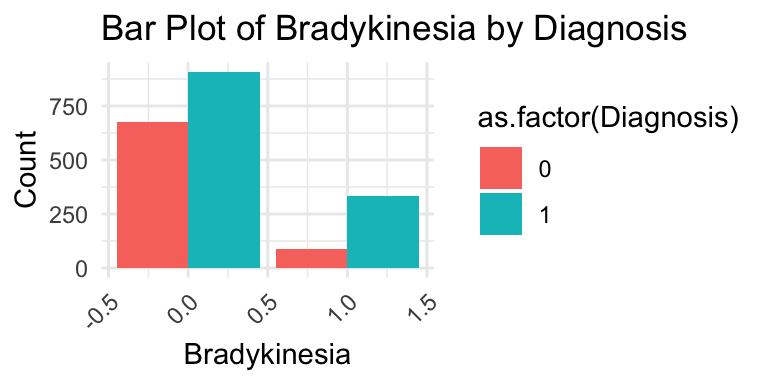

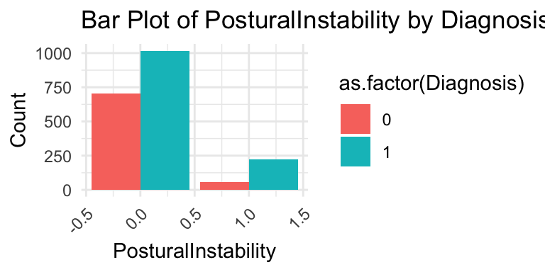

[3 more figures not shown]

```r
cat_features <- names(rf_df)[sapply(rf_df, is.factor) & names(rf_df) != target]  # cat feats have been factorized in rf_df, making them easy to call on
# Plot categorical features using bar plots (grouped by class label)
catDist <- function (df, cat_features, target){
  for (feature in cat_features) {
    print(
      ggplot(df, aes(x = .data[[feature]], fill = as.factor(.data[[target]]))) +
        geom_bar(position = "dodge") +
        labs(title = paste("Bar Plot of", feature, "by", target),
             x = feature, y = "Count") +
        theme_minimal() +
        theme(axis.text.x = element_text(angle = 45, hjust = 1))
    )
  }
}

catDist(clean.train_df, cat_features, target)
```

The visualization of the distribution of categorical features helps identify which features are binary and which are multi-class. This information is useful for choosing appropriate encoding strategies. Additionally, these visualizations can reveal categorical features that show strong relationships with the target variable.

#### Encoding Categorical Features

The only categorical feature requiring encoding is `EducationalLevel.` Since it contains only four classes, I will use one-hot encoding. This will result in three new binary columns (n−1), representing “College”, “High School”, and “Post-Graduate”. A value of 1 in any of these columns indicates that the individual belongs to that educational level. If all three columns are 0, the individual falls into the reference category: “None”.

```r
# create a new df for logistic regression training
logR_df <- clean.train_df %>%
  mutate(College = ifelse(EducationLevel == "College", 1, 0),
         HighSchool = ifelse(EducationLevel == "High School", 1, 0),
         PostGraduate = ifelse(EducationLevel == "Post-Graduate", 1, 0)) %>%
  select(-EducationLevel) #remove original column for training purposes

str(logR_df)
```

```
## 'data.frame':    2001 obs. of  33 variables:
##  $ Age                     : int  85 75 52 87 78 70 80 71 70 53 ...
##  $ BMI                     : num  19.6 16.2 15.5 18.6 30.5 ...
##  $ Smoking                 : int  0 1 0 0 1 1 1 1 0 1 ...
##  $ AlcoholConsumption      : num  5.11 6.03 6 9.78 2.01 ...
##  $ PhysicalActivity        : num  1.38 8.41 1.38 1.19 9.03 ...
##  $ DietQuality             : num  3.89 8.51 6.72 4.66 9.84 ...
##  $ SleepQuality            : num  9.28 5.6 4.2 9.36 5.98 ...
##  $ FamilyHistoryParkinsons : int  0 0 0 0 0 0 0 0 0 0 ...
##  $ TraumaticBrainInjury    : int  0 0 0 0 0 0 0 1 0 0 ...
##  $ Hypertension            : int  0 0 0 0 1 0 0 0 0 0 ...
##  $ Diabetes                : int  0 0 0 0 0 1 1 0 0 0 ...
##  $ Depression              : int  0 0 0 0 0 0 0 1 0 0 ...
##  $ Stroke                  : int  0 0 0 0 0 0 0 0 0 1 ...
##  $ SystolicBP              : int  129 163 146 115 122 129 133 169 138 165 ...
```

[output cut: 19 more lines]

All categorical features originally represented as character strings have been successfully encoded. As a result, the dataset now contains only numeric variables, making it suitable for logistic regression modeling.

#### Multicollinearity

Multicollinearity occurs when two or more features are highly correlated, which can distort the estimated coefficients in a logistic regression model and reduce interpretability. By resolving multicollinearity, we help ensure that the model remains stable, avoids redundancy, and yields interpretable results.

```r
cor(clean.train_df[,numeric_features])
```

```
##                                   Age          BMI AlcoholConsumption
## Age                       1.000000000  0.035381208       -0.014131506
## BMI                       0.035381208  1.000000000        0.012485321
## AlcoholConsumption       -0.014131506  0.012485321        1.000000000
## PhysicalActivity          0.030616310 -0.007333677        0.002389930
## DietQuality               0.007956010  0.006919683        0.003141697
## SleepQuality              0.014187166  0.018879560        0.010605166
## SystolicBP               -0.012373804 -0.017152983        0.002872293
## DiastolicBP               0.013245482  0.013586578       -0.038650419
## CholesterolTotal          0.015762929  0.010061113       -0.013856063
## CholesterolLDL            0.032965058 -0.021763791       -0.005637743
## CholesterolHDL           -0.014940896 -0.026162300       -0.005434571
## CholesterolTriglycerides  0.015006155  0.028413556       -0.045833207
## UPDRS                     0.007326556  0.051571579        0.020114534
## MoCA                     -0.036273514 -0.030260036       -0.010513531
## FunctionalAssessment      0.046344517 -0.013399781        0.002773447
##                          PhysicalActivity  DietQuality  SleepQuality
## Age                          0.0306163096  0.007956010  0.0141871661
## BMI                         -0.0073336771  0.006919683  0.0188795595
## AlcoholConsumption           0.0023899297  0.003141697  0.0106051660
## PhysicalActivity             1.0000000000 -0.019291086  0.0002586815
## DietQuality                 -0.0192910862  1.000000000  0.0390656548
## SleepQuality                 0.0002586815  0.039065655  1.0000000000
## SystolicBP                   0.0059810017  0.004079429 -0.0253217318
## DiastolicBP                 -0.0028847192  0.001221575 -0.0395914358
## CholesterolTotal             0.0181197323  0.005567127  0.0474580650
## CholesterolLDL              -0.0152895393 -0.007177172 -0.0276822155
## CholesterolHDL               0.0172706808  0.026001670  0.0170971168
## CholesterolTriglycerides     0.0451207517 -0.022846679  0.0106698640
## UPDRS                        0.0215661032  0.016918041 -0.0345171248
## MoCA                        -0.0320745320 -0.006993780 -0.0130696399
## FunctionalAssessment         0.0064839917  0.029126832  0.0363003965
##                             SystolicBP  DiastolicBP CholesterolTotal
## Age                      -0.0123738040  0.013245482     0.0157629292
## BMI                      -0.0171529833  0.013586578     0.0100611134
## AlcoholConsumption        0.0028722930 -0.038650419    -0.0138560625
## PhysicalActivity          0.0059810017 -0.002884719     0.0181197323
## DietQuality               0.0040794293  0.001221575     0.0055671270
## SleepQuality             -0.0253217318 -0.039591436     0.0474580650
## SystolicBP                1.0000000000  0.019557147    -0.0007466007
```

[output cut: 25 more lines]

```
## Age                       0.007326556 -0.036273514          0.046344517
## BMI                       0.051571579 -0.030260036         -0.013399781
## AlcoholConsumption        0.020114534 -0.010513531          0.002773447
## PhysicalActivity          0.021566103 -0.032074532          0.006483992
## DietQuality               0.016918041 -0.006993780          0.029126832
## SleepQuality             -0.034517125 -0.013069640          0.036300397
## SystolicBP                0.019278923 -0.002564156          0.028432529
## DiastolicBP              -0.022824734  0.024615523          0.017327086
## CholesterolTotal         -0.016807144 -0.008335296          0.002082611
## CholesterolLDL            0.001793956  0.017275100         -0.013295646
## CholesterolHDL           -0.045163089 -0.004559853          0.008151468
## CholesterolTriglycerides  0.016576803 -0.008079690          0.005174182
## UPDRS                     1.000000000 -0.044782503         -0.001771713
## MoCA                     -0.044782503  1.000000000         -0.012535920
## FunctionalAssessment     -0.001771713 -0.012535920          1.000000000
```

There does not seem to be any multicollinearity observed in the numeric data.

### Split Data

Before training and building our models, we first split the data into training and testing sets, allocating 80% for training and 20% for testing. To ensure reproducibility, we set a random seed prior to performing the split. We used stratified sampling to partition the dataset, preserving the original proportion of class labels (e.g., “0” and “1”) in both training and testing sets. This approach helps prevent class imbalance issues and ensures consistent model evaluation.

Since we plan to build a heterogeneous ensemble consisting of a random forest and a homogeneous logistic regression ensemble, both models will be evaluated on the same test set. For the logistic regression ensemble, we will use the remaining 80% training data to create multiple, different but equally sized training subsets.

#### Random Forest

```r
set.seed(2025)

# Create training index
# 80 for training and 20 for target
train_index <- createDataPartition(rf_df$Diagnosis, p = 0.8, list = F)

train.rf_df <- rf_df[train_index,]
test.rf_df <- rf_df[-train_index,]
```

```r
# original
rf_df.t <- table(rf_df$Diagnosis)
rf_df.n <- round(rf_df.t[1]/nrow(rf_df)*100,2)
rf_df.p <- round(rf_df.t[2]/nrow(rf_df)*100,2)

# training set
train.rf_df.t <- table(train.rf_df$Diagnosis)
train.rf_df.n <- round(train.rf_df.t[1]/nrow(train.rf_df)*100,2)
train.rf_df.p <- round(train.rf_df.t[2]/nrow(train.rf_df)*100,2)

# testing set
test.rf_df.t <- table(test.rf_df$Diagnosis)
test.rf_df.n <- round(test.rf_df.t[1]/nrow(test.rf_df)*100,2)
test.rf_df.p <- round(test.rf_df.t[2]/nrow(test.rf_df)*100,2)
```

Within the original data set, **38.03%** of the data was classified as no for the target variable, while **61.97%** of the data was classified as yes. This class distribution is similarly reflected in the training and test sets, where the proportion of no cases is **38.04%** and **38%**, respectively.

#### Logistic Regression

We first partitioned the dataset using the same training indices as used for the random forest, ensuring that both models share an identical testing set. From the training data, we created five bootstrapped subsets, allowing us to train multiple models on different resampled data. This approach helps reduce variance and provides robustness to class imbalances during model training.

```r
train.logR_df <- logR_df[train_index,] # training set needs to split again later
test.logR_df <- logR_df[-train_index,] # should have the same data as test.rf_df

# 5 partitions for 5 subsets
n.partitions <- 5

# Create lists to hold partitions
partitions <- list()
oob <- list()

# generate partitions with replacement
for (i in 1:n.partitions){
  sampled_index <- sample(1:nrow(train.logR_df),
                          size = round(nrow(train.logR_df)*0.8), # use a smaller sample size to allow for more diversity
                          replace = T)
  partitions[[i]] <- train.logR_df[sampled_index,]
  oob[[i]] <- train.logR_df[-sampled_index,]
}
```

## Models

Before creating our heterogeneous ensemble function, we will first create and train the random forest and homogeneous logistic regression models.

### Random Forest

#### Training

```r
rf_model <- randomForest(Diagnosis ~.,
                         data = train.rf_df,
                         importance = T)
```

#### Evaluation

##### Evaluation

```r
# Predict probabilities for each class
rf_pprob <- predict(rf_model, test.rf_df, type = "prob")

# Convert pos class probabilities to class predictions with 0.5 threshold
rf_predicted <- ifelse(rf_pprob[, "1"] > 0.5, 1, 0)
```

```r
# create function to calc key metrics. Easy to call later
key_metrics <- function(predicted, actual){
  # Build confusion matrix
  confmat <- table(Predicted = predicted, Actual = actual)

  # get values
  TN <- confmat[1,1]
  TP <- confmat[2,2]
  FN <- confmat[1,2]
  FP <- confmat[2,1]

  # calculate
  o_acc <- round((TP + TN)/sum(confmat)*100,2)
  TPR <- round(TP / (TP + FN)*100,2)  # Sensitivity
  TNR <- round(TN / (TN + FP)*100,2) # Specificity
  Precision <- round(TP / (TP + FP)*100,2)
  F1 <- round(2 * Precision * TPR / (Precision + TPR),2)


  # calculate accuracy, TPR, and TNR and display in table
  accuracy <- tibble(
    'Overall Accuracy (%)' = o_acc,
    'True Positive Rate (%)' = TPR,
    'True Negative Rate (%)' = TNR,
    'Precision (%)' = Precision,
    'F1-score (%)' = F1
  )

  return(accuracy)
}

rf_km <- key_metrics(rf_predicted, test.rf_df$Diagnosis)
kable(rf_km) %>% kable_styling()
```

| Overall Accuracy (%) | True Positive Rate (%) | True Negative Rate (%) | Precision (%) | F1-score (%) |
| --- | --- | --- | --- | --- |
| 92.25 | 95.97 | 86.18 | 91.89 | 93.89 |

Overall, the random forest achieves extremely high accuracy along with strong positive and negative predictive performance. The true negative rate (specificity) is slightly lower at 86.18%, but it remains relatively high. Furthermore, the F1-score of 93.89% indicates that the model effectively handles class imbalances. Given the strong performance across key metrics, I do not plan on tuning the random forest further.

### Logistic Regression

#### Training

```r
stepwise_backwards <- function(data, target, threshold){
  # start with previous_many removed
  formula <- paste(target, "~ .")
  model <- glm(as.formula(formula), family = binomial(link = "logit"), data = data)

  # Loop until all p-values <= threshold
  repeat {
    p_values <- summary(model)$coefficients[-1, 4]  # exclude intercept
    max_p <- max(p_values)

    if (max_p <= threshold) {
      break
    }

    # Find the predictor with max p-value
    remove_var <- names(which.max(p_values))

    # Update formula by removing this variable
    formula <- paste(formula, " -", remove_var)

    # Refit model
    model <- glm(as.formula(formula), family = binomial(link = "logit"), data = data)
  }

  return(model)
}

# Usage:
logR_model <- stepwise_backwards(train.logR_df, "Diagnosis", 0.05)
summary(logR_model)
```

```
##
## Call:
## glm(formula = as.formula(formula), family = binomial(link = "logit"),
##     data = data)
##
## Coefficients:
##                       Estimate Std. Error z value Pr(>|z|)
## (Intercept)          -2.883418   0.501904  -5.745 9.19e-09 ***
## Age                   0.020973   0.006120   3.427  0.00061 ***
## Depression            0.410203   0.174397   2.352  0.01867 *
## UPDRS                 0.026443   0.001607  16.453  < 2e-16 ***
## MoCA                 -0.065916   0.008478  -7.774 7.57e-15 ***
## FunctionalAssessment -0.300696   0.027073 -11.107  < 2e-16 ***
## Tremor                2.150836   0.164770  13.054  < 2e-16 ***
## Rigidity              1.951132   0.188518  10.350  < 2e-16 ***
## Bradykinesia          2.127912   0.210762  10.096  < 2e-16 ***
## PosturalInstability   2.015688   0.241842   8.335  < 2e-16 ***
## ---
## Signif. codes:  0 '***' 0.001 '**' 0.01 '*' 0.05 '.' 0.1 ' ' 1
##
## (Dispersion parameter for binomial family taken to be 1)
##
##     Null deviance: 2126.9  on 1600  degrees of freedom
## Residual deviance: 1243.3  on 1591  degrees of freedom
## AIC: 1263.3
##
## Number of Fisher Scoring iterations: 6
```

The features that are statistically significant are `Age`, `Depression`, `UPDRS`, `MoCA`, `FunctionalAssessment`, `Tremor`, `Rigidity`, `Bradykinesia`, and `PosturalInstability`. We will use these features to build the homogeneous ensemble.

```r
# create list for trained model storage
models_v1 <- list()

# iterate through the folds created and train each one (store models in list)
for(i in 1:length(partitions)){
  train.data <- partitions[[i]]
  model <- glm(Diagnosis ~ Age + Depression + UPDRS + MoCA + FunctionalAssessment + Tremor + Rigidity + Bradykinesia + PosturalInstability, family = binomial(link = "logit"), data = train.data)
  models_v1[[i]] <- model
}
```

Now that we have trained all 5 subsets, we will use the models to create the homogeneous ensemble.

```r
logR_ensemble <- function(models, new.data){
  # Predict with each model and store results in a matrix
  predictions <- sapply(models, function(model) {
    predict(model, newdata = new.data, type = "response")
  })

  # If only one row in new.data, predictions will be a vector; convert to matrix
  if (is.vector(predictions)) {
    predictions <- matrix(predictions, nrow = 1)
  }

  # Row-wise average of predictions
  avg_pprob <- rowMeans(predictions)

  # Return converted pos class probabilities to class predictions with 0.5 threshold
  return(avg_pprob)
}
```

#### Evaluation

We will now evaluate the homogeneous logistic regression model we have created using the key metrics we used before: accuracy, true positive rate, true negative rate, precision, and F1 score.

```r
logR_pprob <- logR_ensemble(models_v1, test.logR_df)
logR_predict <- ifelse(logR_pprob > 0.5, 1, 0)
```

```r
logR_km <- key_metrics(logR_predict, test.logR_df$Diagnosis)
kable(logR_km) %>% kable_styling()
```

| Overall Accuracy (%) | True Positive Rate (%) | True Negative Rate (%) | Precision (%) | F1-score (%) |
| --- | --- | --- | --- | --- |
| 82 | 87.9 | 72.37 | 83.85 | 85.83 |

The logistic regression ensemble has a decent overall accuracy and a strong true positive rate. The high recall and F1-score suggest that the model is effective at detecting the positive class. However, it struggles somewhat with identifying the negative class, which may be attributed to the class imbalance present in the data.

```r
models_v2 <- list()

for(i in 1:length(partitions)){
  train.data <- partitions[[i]]
  model <- stepwise_backwards(train.data, "Diagnosis", 0.05)
  models_v2[[i]] <- model
}

# logR predictions
logR_pprob2 <- logR_ensemble(models_v2, test.logR_df)
logR_predict2 <- ifelse(logR_pprob2 > 0.5, 1, 0)

# key metrics
logR_km2 <- key_metrics(logR_predict2, test.logR_df$Diagnosis)

# Display key metrics for different logistic regression models
logR_combined <- bind_rows(logR_km, logR_km2) %>%
  mutate(Version = c("1", "2")) %>%
  select(Version, everything())
kable(logR_combined, caption="Key Metrics")%>%
  kable_styling()
```

Key Metrics

| Version | Overall Accuracy (%) | True Positive Rate (%) | True Negative Rate (%) | Precision (%) | F1-score (%) |
| --- | --- | --- | --- | --- | --- |
| 1 | 82.00 | 87.90 | 72.37 | 83.85 | 85.83 |
| 2 | 82.25 | 89.11 | 71.05 | 83.40 | 86.16 |

Overall, the second logistic regression model—trained using stepwise backward elimination across all models—demonstrated stronger balanced performance. Although it has a slightly lower true negative rate, prioritizing the correct prediction of positive diagnoses is more critical. Therefore, we will select the second logistic regression model for inclusion in the ensemble.

### Ensemble

```r
ensemble <- function(rf, logR, rf_test, logR_test){
  # Predict probabilities for each class
  rf_pprob <- predict(rf, rf_test, type = "prob")
  logR_pprob <- logR_ensemble(logR, logR_test)

  # Combine into a matrix to calculate row-wise mean
  ## we only want the positive class of the rf prediction
  combined_probs <- cbind(rf_pprob[,"1"], logR_pprob)
  avg_pprob <- rowMeans(combined_probs)

  prediction <- ifelse(avg_pprob > 0.5, 1, 0)

  return(prediction)
}
```

#### Evaluation

```r
# Make ensemble prediction
ensemble_predict <- ensemble(rf_model, models_v2, test.rf_df, test.logR_df)

# Calculate key metrics
ensemble_km <- key_metrics(ensemble_predict, test.logR_df$Diagnosis) # The diagnosis is the same for both test sets

# Display table
combined_km <- bind_rows(rf_km, logR_km, ensemble_km) %>%
  mutate(Model = c("Random Forest", "Logistic Regression Ensemble", "Ensemble")) %>%
  select(Model, everything())
kable(combined_km, caption="Key Metrics")%>%
  kable_styling()
```

Key Metrics

| Model | Overall Accuracy (%) | True Positive Rate (%) | True Negative Rate (%) | Precision (%) | F1-score (%) |
| --- | --- | --- | --- | --- | --- |
| Random Forest | 92.25 | 95.97 | 86.18 | 91.89 | 93.89 |
| Logistic Regression Ensemble | 82.00 | 87.90 | 72.37 | 83.85 | 85.83 |
| Ensemble | 91.75 | 96.77 | 83.55 | 90.57 | 93.57 |

Overall, the ensemble model performed very well, achieving key metric values comparable to those of the individual random forest model. However, the random forest still slightly outperformed the ensemble across most metrics. As a result, we will modify the ensemble to assign greater weight to the random forest predictions, given its stronger individual performance.

#### Tuning

```r
weighted_ensemble <- function(rf, logR, rf_test, logR_test, weight){
  # Predict probabilities for each class
  rf_pprob <- predict(rf, rf_test, type = "prob")
  logR_pprob <- logR_ensemble(logR, logR_test)

  # Weighted average: 70% RF, 30% logistic regression
  avg_pprob <- weight * rf_pprob[,"1"] + (1-weight) * logR_pprob

  prediction <- ifelse(avg_pprob > 0.5, 1, 0)

  return(prediction)
}
```

```r
weights <- c(0.6, 0.7, 0.8, 0.9)
weighted_results <- lapply(weights, function(w) {
  prediction <- weighted_ensemble(rf_model, models_v2, test.rf_df, test.logR_df, w)
  metrics <- key_metrics(prediction, test.logR_df$Diagnosis)
  metrics$Model <- "Weighted Ensemble"
  metrics$Weight <- w
  return(metrics)
})


# display weighted ensemble vs other models
combined<- bind_rows(combined_km, weighted_results) %>%
  select(Model, Weight, everything()) %>%
  rename("Random Forest Weight" = Weight)
kable(combined, caption="Key Metrics")%>%
  kable_styling()
```

Key Metrics

| Model | Random Forest Weight | Overall Accuracy (%) | True Positive Rate (%) | True Negative Rate (%) | Precision (%) | F1-score (%) |
| --- | --- | --- | --- | --- | --- | --- |
| Random Forest | NA | 92.25 | 95.97 | 86.18 | 91.89 | 93.89 |
| Logistic Regression Ensemble | NA | 82.00 | 87.90 | 72.37 | 83.85 | 85.83 |
| Ensemble | NA | 91.75 | 96.77 | 83.55 | 90.57 | 93.57 |
| Weighted Ensemble | 0.6 | 92.75 | 97.98 | 84.21 | 91.01 | 94.37 |
| Weighted Ensemble | 0.7 | 92.25 | 97.58 | 83.55 | 90.64 | 93.98 |
| Weighted Ensemble | 0.8 | 93.00 | 97.98 | 84.87 | 91.35 | 94.55 |
| Weighted Ensemble | 0.9 | 92.75 | 97.18 | 85.53 | 91.63 | 94.32 |

Adding weight to the random forest model improved the ensemble’s overall performance. The weighted ensemble outperformed the individual random forest model. A weight of 0.8 for the random forest model, resulted in the highest overall accuracy, true positive rate, and F1-score. This indicates that the model was well balanced and was best at minimizing false negatives and avoiding missed diagnoses. Therefore, the ensemble model with a random forest weight of 0.8 is the most preferable version.

## Model Validation

#### Read Validation Data Set

```r
val_url <- "https://s3.us-east-2.amazonaws.com/artificium.us/datasets/parkinsons-diagnostic-validation-100.csv"

val_df <- read.csv(val_url, stringsAsFactors = F, header = T)
```

#### Validation Data Prep

Before predicting the diagnosis for the validation set, we must preprocess the data using the same transformations applied to the training sets to ensure consistency in the ensemble model.

```r
# remove the same columns as in training dataset prep
clean.val_df <- val_df %>%
  select(-Ethnicity, -PatientID, -Gender)

# factorize categorical features for rf
val.rf_df <- clean.val_df %>%
  mutate(across(c(EducationLevel, Smoking,
                  FamilyHistoryParkinsons, TraumaticBrainInjury,
                  Hypertension, Diabetes, Depression, Stroke, Tremor,
                  Rigidity, Bradykinesia, PosturalInstability,
                  SpeechProblems, SleepDisorders, Constipation),
                as.factor))

# encode categorical for logistic regression
val.logR_df <- clean.val_df %>%
  mutate(College = ifelse(EducationLevel == "College", 1, 0),
         HighSchool = ifelse(EducationLevel == "High School", 1, 0),
         PostGraduate = ifelse(EducationLevel == "Post-Graduate", 1, 0)) %>%
  select(-EducationLevel)
```

#### Predict Validation Set

We will apply the weighted ensemble model to predict the diagnosis in the validation set, using a weight of 0.8 for the random forest component based on prior performance.

```r
pred_val <- weighted_ensemble(rf_model, models_v2, val.rf_df, val.logR_df, 0.8)
```

#### Save Predicted Diagnosis to CSV

```r
save_df <- val_df %>%
  mutate(Diagnosis = pred_val) %>%
  select(PatientID, Diagnosis) %>%
  arrange(PatientID)

write.csv(save_df, "Parkinsons.Predictions.csv", row.names = FALSE)
```